# Matching with Clustered Data: the CMatching Package in R

Matching is a well known technique to balance covariates distribution between treated and control units in non-experimental studies. In many fields, clustered data are a very common occurrence in the analysis of observational data and the clustering can add potentially interesting information. Matching algorithms should be adapted to properly exploit the hierarchical structure. In this article we present the CMatching package implementing matching algorithms for clustered data. The package provides functions for obtaining a matched dataset along with estimates of most common parameters of interest and model-based standard errors. A propensity score matching analysis, relating math proficiency with homework completion for students belonging to different schools (based on the NELS-88 data), illustrates in detail the use of the algorithms.

Massimo Cannas (University of Cagliari) , Bruno Arpino (University of Florence)  
2019-08-15

## 1 Background

Causal inference with observational data usually requires a preliminary stage of analysis corresponding to the *design* stage of an experimental study. The aim of this preliminary stage is to reduce the imbalance in covariates distribution across treated and untreated units due the non-random assignment of treatment before estimating the parameters of interest. Matching estimators are widely used for this task (Stuart 2010). Matching can be done directly on the covariates (multivariate matching) or on the propensity score (Rosenbaum and Rubin 1983). The latter is defined as the probability of the treatment given the covariates value and it has a central role for the estimation of causal effects. In fact, the propensity score is a one dimensional summary of the covariates and thus it mitigates the difficulty of matching observations in high dimensional spaces. Propensity score methods have flourished and several techniques are now well established both in theory and in practice, including stratification on the propensity score, propensity score weighting (PSW), and propensity score matching (PSM).

Whilst the implementation of matching techniques with unstructured data has became a standard tool for researchers in several fields (Imbens and Rubin 2016), the increasing availability of clustered (nested, hierarchical) observational data poses new challenges. In a clustered observational study individuals are partitioned into clusters and the treatment is non-randomly assigned in each cluster so that confounders may exist both at the individual and at the cluster level. Note that this framework is different from clustered observational data where a treatment is non-randomly assigned for all units in the cluster, for which an optimal matching strategy has been suggested by Zubizarreta and Keele (2017). Such nested data structures are ubiquitous in the health and social sciences where patients are naturally clustered in hospitals and students in schools, just to make two notable examples. If relevant confounders are observed at both levels then a standard analysis, adjusting for all confounders, seems reasonable. However, when only the cluster label — but not the cluster level variables — is observed there is not a straightforward strategy to exploit the information on the clustering. Intuitively, the researcher having a strong belief on the importance of the cluster level confounders may adopt a ‘*within-cluster*’ matching strategy. On the other extreme, a researcher may decide to ignore the clustering by using only the *pooled* data. It is important to note that this pooling strategy implicitly assumes that cluster level variables are not important confounders. Indeed, there have been a few proposals to adapt PSW and PSM to clustered data, see Cafri et al. (2018) for a review. Li et al. (2013) proposed several propensity score weighting algorithms for clustered data showing, both analytically and by simulation, that they reduce the bias of causal effects estimators when "clusters matter," that is, when cluster level covariates are important confounders. In the PSM context, Arpino and Mealli (2011) proposed to account for the clustering in the estimation of the propensity score via multilevel models. Recently, Rickles and Seltzer (2014) and Arpino and Cannas (2016) proposed caliper matching algorithms to perform PSM with clustered data. As we will discuss shortly, these algorithms can be used not only for PSM but also in the more general context of multivariate matching.

In the remaining of this paper, after reviewing the basic ideas underlying matching estimators, we briefly describe the available packages for matching in the R environment. Then, we describe the algorithms for matching with clustered data proposed by Arpino and Cannas (2016) and we present the package [*CMatching*](https://CRAN.R-project.org/package=CMatching) implementing these algorithms. The applicability of these algorithms is very broad and refers to all situations where cluster-level data are present (in medicine, epidemiology, economics, etc.). A section is devoted to illustrate the use of the package on data about students and schools, which is a common significant occurrence of clustered data.

## 2 Packages for matching unstructured data in R

A list of the most important packages for matching available for R users is shown in Table 1. The [*Matching*](https://CRAN.R-project.org/package=Matching) package, which is required to run *CMatching*, is a remarkably complete package offering several matching options. `Matching` implements many greedy matching algorithms including genetic matching (Diamond and Sekhon 2013). It also contains a general `MatchBalance` function to measure pre- and post-matching balance with a large suite of diagnostics. As for optimal matching, there are dedicated packages like [*designmatch*](https://CRAN.R-project.org/package=designmatch) and [*optmatch*](https://CRAN.R-project.org/package=optmatch). The latter can also be called from [*MatchIT*](https://CRAN.R-project.org/package=MatchIT), a general purpose package implementing also the Coarsened Exact Matching approach of (Iacus et al. 2011). Full matching is a particular form of optimal matching implemented by [*quickmatch*](https://CRAN.R-project.org/package=quickmatch) with several custom options.

Table 1: General purpose packages available from CRAN implementing matching algorithms. The list is not exhaustive as there are several packages covering specialized matching routines: a list can be found at [http://www.biostat.jhsph.edu/ estuart/propensityscoresoftware.html](http://www.biostat.jhsph.edu/~estuart/propensityscoresoftware.html).

| `Package` | `Description` | `Reference` |  |
| --- | --- | --- | --- |
| *Matching* | Greedy matching and balance analysis | (Sekhon 2011) |  |
| *MatchIT* | Greedy matching and balance analysis | (Iacus et al. 2011) |  |
| *optmatch* | Optimal matching | (Hansen and Klopfer 2006) |  |
| *quickmatch* | Generalized full matching | (Savje et al. 2018) |  |
| *designmatch* | Optimal matching and designs | (Zubizarreta et al. 2018) |  |

At the time of writing none of the packages described above offers specific routines for clustered data. The *CMatching* package fills this important gap implementing the algorithms for matching clustered data described in the next section.

## 3 Matching clustered data

Let us consider a clustered data structure ${\mathfrak D} = \{ y_{i j}, x_{i j} , t_{i j} \}, \quad i=1,\cdots n_j, \quad j=1,\cdots J$. For observation $i$ in cluster $j$ we observe a vector of covariates $X$ and a binary variable $T$ specifying the treatment status of each observation. Here $n=\sum n_j$ is the total number of observations and $J$ is the number of clusters in the data. We observe also a response variable $Y$ whose average value we are willing to compare across treated and untreated units. A matching algorithm assigns a (possibly empty) subset of control units to each treated unit. The assignment is made with the aim of minimizing a loss function, typically expressed in terms of covariates distance between treated and untreated units. Matching algorithms can be classified as greedy or optimal depending whether the cost function is minimized locally or globally, respectively. Optimal matching algorithms are not affected by the order of the units being matched so they can reach the global optimum, but they are typically more computer-intensive than greedy algorithms proceedings step by step. To bound the possibility of bad matches in greedy matching, it is customary to define a maximum distance for two units to be matched, i.e., a *caliper*, which is usually expressed in standard deviation units of the covariates (or of the propensity score). A greedy matching procedure can then be articulated in the following steps:

1. fix the caliper;
2. match each treated with control unit(s) at minimum covariates distance (provided that distance < caliper);
3. measure the residual covariates’ imbalance in the matched dataset and count the number of unmatched units (drops);
4. carefully consider both the balance and the number of drops: if they are satisfactory then proceed to the outcome analysis; otherwise stop or revise previous steps.

If matching proves successful in adjusting covariates, the researcher can proceed to outcome analysis where the causal estimand of interest is estimated from the matched data using a variety of techniques (Ho et al. 2007). On the other hand, if the procedure gives either an unsatisfactory balance or an excessive number of unmatched units, the investigator may try to modify some aspects of the procedure (e.g., the caliper, the way the distance is calculated).

Conceptually, the same procedure can be used also for hierarchical data. Indeed, it is not atypical to find analysis ignoring the clustering and pooling together all units. A pooling strategy implicitly assumes that the clustering is not relevant. However, in several cases the clustering does matter, that is, the researcher can hypothesize or suspect that some important cluster-level confounders are unobserved. In this case, the information on the cluster labels can be exploited in at least two ways: i) forcing the matching to be implemented *within-cluster* only; ii) performing a *preferential* within-cluster matching, an intermediate approach between the two extremes of pooled and within-cluster matching (Arpino and Cannas 2016). A within-cluster matching can be obtained by modifying step 2 above in the following way:

1. match each treated with the control unit(s) *in group $j$* at minimum covariate distance (provided that distance < caliper).

This procedure may result in a large number of unmatched units (drops) so it increases the risk of substantial bias due to incomplete matching (Rosenbaum and Rubin 1985), in particular when the clusters are small. This particular bias arises when a matched subset is not representative of the original population of treated units because of several *non random* drops. Even in the absence of bias due to incomplete matching, a high number of drops reduces the original sample size with possible negative consequences in terms of higher standard errors.

It is possible to profit as much as possible of the the exact balance of (unobserved) cluster-level covariates by first matching within clusters and then recovering some unmatched treated units in a second stage. This leads to the preferential within-cluster matching, which can be obtained by modifying step 2 above in the following way:

1. *a)* match each treated with the control units(s) *in group $j$* at minimum covariate distance (distance < caliper);
2. *b)* match each unmatched treated unit from previous step with the control unit(s) at minimum covariate distance in some group different from $j$ (provided that distance < caliper).

Now consider the outcome variable $Y$. We can define for each unit potential outcomes $Y1,\, Y0$ as the outcome we would observe under assignment to the treatment and control group, respectively (Holland 1986). Causal estimands of interest are the Average Treatment effect: $ATE= E[Y1-Y0]$ or, more often, the Average Treatment effect on the treated: $ATT= T E[Y1-Y0]$. Given that a unit is either assigned to the treatment or control group it is not possible to directly observe the individual causal effect on each unit; we have $Y=T\cdot Y1+(1-T)\cdot Y0$. In a randomized study $T$ is independent of $(Y0,Y1)$ so, for $k=0,1$, we have
$$E(Yk)=E(Yk\, |\, T=k)=E(Y \, |\, T=k)$$
which can be estimated from the observed data. In a observational study, matching can be used to balance covariates across treated and control units and then the previous relation can be exploited to impute the unobserved potential outcomes from the *matched dataset*. In our clustered data context, after the matched dataset has been created using one of the algorithms above, the ATT and its standard error can be estimated using a simple regression model:
$$Y_{ij}=\alpha_{j} + T_{ij}\beta
\label{model} \tag{1}$$
that is, a linear regression model with clustered standard errors to take into account within-cluster dependence in the outcome (Arpino and Cannas 2016). The resulting ATT estimate is the difference of outcome means across treated and controls, i.e., $\widehat{ATT}\coloneqq mean(Y \, | \, T=1) - mean(Y \, | \, T=0)$, computed on the matched data. Standard errors are calculated using the cluster bootstrapping method for estimating variance-covariance matrices proposed by Cameron et al. (2011) and implemented in the package [*multiwayvcov*](https://CRAN.R-project.org/package=multiwayvcov). In general, calculating standard errors for PSM in clustered observational studies is a difficult problem requiring prudence from the researcher. While close formulae exist for weighting estimators (Li et al. 2013), standard error estimation after PSM matching relies upon approximation (Cafri et al. 2018), modelling assumption (Arpino and Cannas 2016), or simulation (Rickles and Seltzer 2014).

### 3.1 Multisets and matching output

In this section we briefly detail the two routines in the *CMatching* package. Multisets are useful to compactly describe pseudo code so we recall some definitions and basic properties herein. A multiset is a pair $\{U,m\}$ where $U$ is a given set, usually called universe, and $m:x\rightarrow \mathbb{N}\cup\{0\}$ is the multiplicity function assigning each $x\in U$ its frequency in $U$. Both the summation symbol and union symbols are used to manipulate multisets and they have different meanings: if $A$ and $B$ are multisets then $C\equiv A \cup B$ is defined by $m_C(x)=max(m_A(x),m_B(x))$, while $C\equiv A+B$ is defined by $m_C(x)=m_A(x)+m_B(x)$. For example if $A\equiv\{1,2,2\}$ and $B\equiv\{1,2,3\}$ then $A\cup B\equiv \{1,2,2,3\}$, $A+B\equiv \{1,1,2,2,2,3\}$. In our framework $U$ is the set of observations indexes and thus $m$ gives information about the number of times a given observation occurred in the matched dataset. Multisets then allow to naturally represent multiple matches arising from matching with replacement. When using multiset notation to describe the output of a matching algorithm, we are implicitly overlooking the fact that the output of a matching algorithm is richer as it also brings out the pairings, i.e., the associations between matched treated and untreated observations. However, it can be noted that this pairing is not relevant for calculating common estimates or common balance measures (e.g., the ATT), as they are invariant to permutations of the labels of the matched observations.

### 3.2 The routines `MatchW` and `MatchPW`

We denote with $W_i$ and $\overline{W}_i$ the sets of treated observations matched within clusters and unmatched within clusters, respectively. In Algorithms 1 and 2 the summation symbol $(\sum)$ denotes multiset sum.

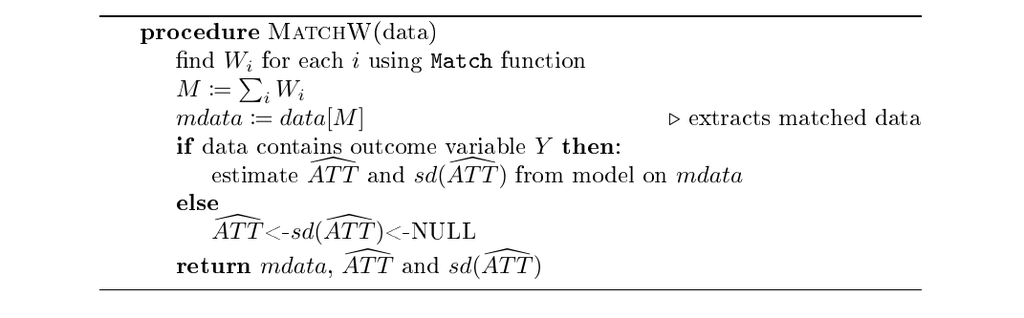

Algorithm 1: Algorithm for within-cluster matching

In the first two lines, common to both algorithms, the `Match` function is repeatedly run to produce the matched-within subsets $M_i$ $i=,...,J$. Then, in algorithm 1 the sum of the $M_i$ in line 3 gives the matched subset $M$. Algorithm 2 is similar but after finding the $M_i$’s an "additional" subset $B$ is found by recovering some unmatched units (line 3) and then combined to give the final matched dataset. If a response variable $Y$ was included the output of both algorithms also contains an estimate of the ATT (default, but the user can choose also other estimands) and its standard error.

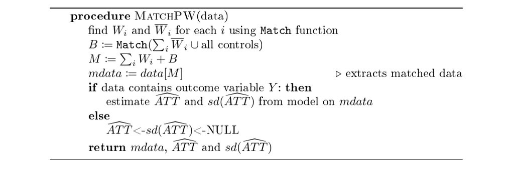

Algorithm 2: Algorithm for preferential within-cluster matching

## 4 Functions in the CMatching package

*CMatching* can be freely downloaded from CRAN repository and it contains the functions listed in Table 2. The main function `CMatch` performs within-cluster and preferential within-cluster matching via subfunctions `MatchW` and `MatchPW`, respectively. The output of the main function can be passed to functions `CMatchBalance` and `summary` to provide summaries of covariates balance and other characteristics of the matched dataset. `CMatch` exploits the `Match` function (see *Matching*) implementing matching for unstructured data. Given a covariate `X` and a binary treatment `T`, the call `Match(X, T, ...)` gives the set of indexes of matched treated and matched control units. The `CMatch` function has the same arguments plus the optional arguments `G` (specifying the cluster variable) and `type` to choose between within-cluster matching or preferential-within-cluster matching. We highlight that we chose to frame the *CMatch* in the `Match` function style so that `Matching` users can easily implement PSM with clustered data in a familiar setting.

Table 2: Main input and output of functions in *CMatching* package.

| **Function** | **Description** | Input | Output |
| --- | --- | --- | --- |
| `CMatch` | Match | $X,\,T,\, G$ | A matched dataset |
| `MatchW` | Match within | $X,\,T,\, G$ | A matched dataset |
| `MatchPW` | Match preferentially within | $X,\,T,\, G$ | A matched dataset |
| `summary.Match` | S3 method for CMatch objects | A matched dataset | General summaries |
| `CMatchBalance` | Balance analysis | A matched dataset | Balance summaries |

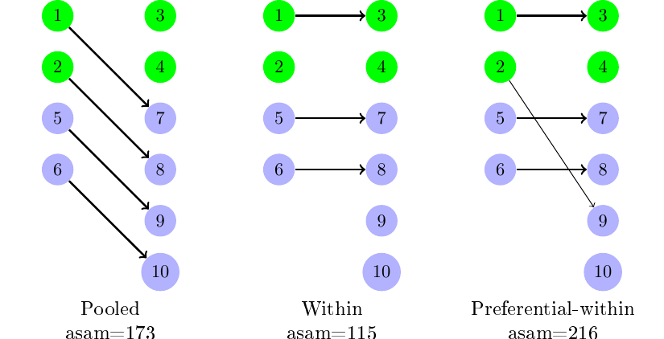

Figure 1: Different matching solutions for the toy dataset (`caliper = 2`). Green and violet circles indicate cluster 1 and cluster 2 units, respectively; arrows indicate matched pairs of treated (left) and control units (right). For each matching we report the absolute percent standardized mean difference of $x$ in the matched subset (`asam)`, a measure of residual imbalance.